# Risk Factor Analysis

## Outcome Variable

**Outcome Variable:** ever_swasted

## Predictor Variables

**Intervention Variable:** mwtkg

**Adjustment Set:**

- arm
- W_mage
- meducyrs
- feducyrs
- W_nchldlt5
- brthmon
- W_parity
- delta_W_mage
- delta_meducyrs
- delta_feducyrs
- delta_W_nchldlt5
- delta_brthmon
- delta_W_parity

## Stratifying Variables

The analysis was stratified on these variable(s):

- agecat
- studyid
- country

## Data Summary

| agecat | studyid | country | mwtkg | ever_swasted | n_cell | n |
| --- | --- | --- | --- | --- | --- | --- |
| 0-24 months | iLiNS-Zinc | BURKINA FASO | >=58 kg | 0 | 906 | 3217 |
| 0-24 months | iLiNS-Zinc | BURKINA FASO | >=58 kg | 1 | 31 | 3217 |
| 0-24 months | iLiNS-Zinc | BURKINA FASO | <52 kg | 0 | 1124 | 3217 |
| 0-24 months | iLiNS-Zinc | BURKINA FASO | <52 kg | 1 | 77 | 3217 |
| 0-24 months | iLiNS-Zinc | BURKINA FASO | [52-58) kg | 0 | 1033 | 3217 |
| 0-24 months | iLiNS-Zinc | BURKINA FASO | [52-58) kg | 1 | 46 | 3217 |
| 0-24 months | JiVitA-3 | BANGLADESH | >=58 kg | 0 | 634 | 26925 |
| 0-24 months | JiVitA-3 | BANGLADESH | >=58 kg | 1 | 27 | 26925 |
| 0-24 months | JiVitA-3 | BANGLADESH | <52 kg | 0 | 23001 | 26925 |
| 0-24 months | JiVitA-3 | BANGLADESH | <52 kg | 1 | 1505 | 26925 |
| 0-24 months | JiVitA-3 | BANGLADESH | [52-58) kg | 0 | 1645 | 26925 |
| 0-24 months | JiVitA-3 | BANGLADESH | [52-58) kg | 1 | 113 | 26925 |
| 0-24 months | LCNI-5 | MALAWI | >=58 kg | 0 | 113 | 838 |
| 0-24 months | LCNI-5 | MALAWI | >=58 kg | 1 | 1 | 838 |
| 0-24 months | LCNI-5 | MALAWI | <52 kg | 0 | 500 | 838 |
| 0-24 months | LCNI-5 | MALAWI | <52 kg | 1 | 4 | 838 |
| 0-24 months | LCNI-5 | MALAWI | [52-58) kg | 0 | 217 | 838 |
| 0-24 months | LCNI-5 | MALAWI | [52-58) kg | 1 | 3 | 838 |
| 0-24 months | MAL-ED | BANGLADESH | >=58 kg | 0 | 45 | 254 |
| 0-24 months | MAL-ED | BANGLADESH | >=58 kg | 1 | 3 | 254 |
| 0-24 months | MAL-ED | BANGLADESH | <52 kg | 0 | 144 | 254 |
| 0-24 months | MAL-ED | BANGLADESH | <52 kg | 1 | 18 | 254 |
| 0-24 months | MAL-ED | BANGLADESH | [52-58) kg | 0 | 44 | 254 |
| 0-24 months | MAL-ED | BANGLADESH | [52-58) kg | 1 | 0 | 254 |
| 0-24 months | MAL-ED | BRAZIL | >=58 kg | 0 | 140 | 221 |
| 0-24 months | MAL-ED | BRAZIL | >=58 kg | 1 | 3 | 221 |
| 0-24 months | MAL-ED | BRAZIL | <52 kg | 0 | 42 | 221 |
| 0-24 months | MAL-ED | BRAZIL | <52 kg | 1 | 0 | 221 |
| 0-24 months | MAL-ED | BRAZIL | [52-58) kg | 0 | 35 | 221 |
| 0-24 months | MAL-ED | BRAZIL | [52-58) kg | 1 | 1 | 221 |

[output cut: 270 more lines]

The following strata were considered:

- agecat: 0-24 months, studyid: iLiNS-Zinc, country: BURKINA FASO
- agecat: 0-24 months, studyid: JiVitA-3, country: BANGLADESH
- agecat: 0-24 months, studyid: LCNI-5, country: MALAWI
- agecat: 0-24 months, studyid: MAL-ED, country: BANGLADESH
- agecat: 0-24 months, studyid: MAL-ED, country: BRAZIL
- agecat: 0-24 months, studyid: MAL-ED, country: INDIA
- agecat: 0-24 months, studyid: MAL-ED, country: NEPAL
- agecat: 0-24 months, studyid: MAL-ED, country: PERU
- agecat: 0-24 months, studyid: MAL-ED, country: SOUTH AFRICA
- agecat: 0-24 months, studyid: MAL-ED, country: TANZANIA, UNITED REPUBLIC OF
- agecat: 0-24 months, studyid: NIH-Birth, country: BANGLADESH
- agecat: 0-24 months, studyid: NIH-Crypto, country: BANGLADESH
- agecat: 0-24 months, studyid: PROBIT, country: BELARUS
- agecat: 0-24 months, studyid: PROVIDE, country: BANGLADESH
- agecat: 0-24 months, studyid: SAS-CompFeed, country: INDIA
- agecat: 0-24 months, studyid: TanzaniaChild2, country: TANZANIA, UNITED REPUBLIC OF
- agecat: 0-24 months, studyid: ZVITAMBO, country: ZIMBABWE
- agecat: 0-6 months, studyid: JiVitA-3, country: BANGLADESH
- agecat: 0-6 months, studyid: LCNI-5, country: MALAWI
- agecat: 0-6 months, studyid: MAL-ED, country: BANGLADESH
- agecat: 0-6 months, studyid: MAL-ED, country: BRAZIL
- agecat: 0-6 months, studyid: MAL-ED, country: INDIA
- agecat: 0-6 months, studyid: MAL-ED, country: NEPAL
- agecat: 0-6 months, studyid: MAL-ED, country: PERU
- agecat: 0-6 months, studyid: MAL-ED, country: SOUTH AFRICA
- agecat: 0-6 months, studyid: MAL-ED, country: TANZANIA, UNITED REPUBLIC OF
- agecat: 0-6 months, studyid: NIH-Birth, country: BANGLADESH
- agecat: 0-6 months, studyid: NIH-Crypto, country: BANGLADESH
- agecat: 0-6 months, studyid: PROBIT, country: BELARUS
- agecat: 0-6 months, studyid: PROVIDE, country: BANGLADESH
- agecat: 0-6 months, studyid: SAS-CompFeed, country: INDIA
- agecat: 0-6 months, studyid: TanzaniaChild2, country: TANZANIA, UNITED REPUBLIC OF
- agecat: 0-6 months, studyid: ZVITAMBO, country: ZIMBABWE
- agecat: 6-24 months, studyid: iLiNS-Zinc, country: BURKINA FASO
- agecat: 6-24 months, studyid: JiVitA-3, country: BANGLADESH
- agecat: 6-24 months, studyid: LCNI-5, country: MALAWI
- agecat: 6-24 months, studyid: MAL-ED, country: BANGLADESH
- agecat: 6-24 months, studyid: MAL-ED, country: BRAZIL
- agecat: 6-24 months, studyid: MAL-ED, country: INDIA
- agecat: 6-24 months, studyid: MAL-ED, country: NEPAL
- agecat: 6-24 months, studyid: MAL-ED, country: PERU
- agecat: 6-24 months, studyid: MAL-ED, country: SOUTH AFRICA
- agecat: 6-24 months, studyid: MAL-ED, country: TANZANIA, UNITED REPUBLIC OF
- agecat: 6-24 months, studyid: NIH-Birth, country: BANGLADESH
- agecat: 6-24 months, studyid: NIH-Crypto, country: BANGLADESH
- agecat: 6-24 months, studyid: PROBIT, country: BELARUS
- agecat: 6-24 months, studyid: PROVIDE, country: BANGLADESH
- agecat: 6-24 months, studyid: SAS-CompFeed, country: INDIA
- agecat: 6-24 months, studyid: TanzaniaChild2, country: TANZANIA, UNITED REPUBLIC OF
- agecat: 6-24 months, studyid: ZVITAMBO, country: ZIMBABWE

### Dropped Strata

Some strata were dropped due to rare outcomes:

- agecat: 0-24 months, studyid: LCNI-5, country: MALAWI
- agecat: 0-24 months, studyid: MAL-ED, country: BANGLADESH
- agecat: 0-24 months, studyid: MAL-ED, country: BRAZIL
- agecat: 0-24 months, studyid: MAL-ED, country: INDIA
- agecat: 0-24 months, studyid: MAL-ED, country: NEPAL
- agecat: 0-24 months, studyid: MAL-ED, country: PERU
- agecat: 0-24 months, studyid: MAL-ED, country: SOUTH AFRICA
- agecat: 0-24 months, studyid: MAL-ED, country: TANZANIA, UNITED REPUBLIC OF
- agecat: 0-24 months, studyid: PROVIDE, country: BANGLADESH
- agecat: 0-6 months, studyid: LCNI-5, country: MALAWI
- agecat: 0-6 months, studyid: MAL-ED, country: BANGLADESH
- agecat: 0-6 months, studyid: MAL-ED, country: BRAZIL
- agecat: 0-6 months, studyid: MAL-ED, country: INDIA
- agecat: 0-6 months, studyid: MAL-ED, country: NEPAL
- agecat: 0-6 months, studyid: MAL-ED, country: PERU
- agecat: 0-6 months, studyid: MAL-ED, country: SOUTH AFRICA
- agecat: 0-6 months, studyid: MAL-ED, country: TANZANIA, UNITED REPUBLIC OF
- agecat: 0-6 months, studyid: NIH-Birth, country: BANGLADESH
- agecat: 0-6 months, studyid: PROVIDE, country: BANGLADESH
- agecat: 6-24 months, studyid: LCNI-5, country: MALAWI
- agecat: 6-24 months, studyid: MAL-ED, country: BANGLADESH
- agecat: 6-24 months, studyid: MAL-ED, country: BRAZIL
- agecat: 6-24 months, studyid: MAL-ED, country: INDIA
- agecat: 6-24 months, studyid: MAL-ED, country: NEPAL
- agecat: 6-24 months, studyid: MAL-ED, country: PERU
- agecat: 6-24 months, studyid: MAL-ED, country: SOUTH AFRICA
- agecat: 6-24 months, studyid: MAL-ED, country: TANZANIA, UNITED REPUBLIC OF
- agecat: 6-24 months, studyid: NIH-Birth, country: BANGLADESH
- agecat: 6-24 months, studyid: NIH-Crypto, country: BANGLADESH
- agecat: 6-24 months, studyid: PROBIT, country: BELARUS
- agecat: 6-24 months, studyid: PROVIDE, country: BANGLADESH

## Methods Detail

We’re interested in the causal parameters $E[Y_a]$ for all values of $a \in \mathcal{A}$. These parameters represent the mean outcome if, possibly contrary to fact, we intervened to set all units to have $A=a$. Under the randomization and positivity assumptions, these are identified by the statistical parameters $\psi_a=E_W[E_{Y|A,W}(Y|A=a,W)]$. In addition, we’re interested in the mean of $Y$, $E[Y]$ under no intervention (the observed mean). We will estimate these parameters by using SuperLearner to fit the relevant likelihood factors – $E_{Y|A,W}(Y|A=a,W)$ and $p(A=a|W)$, and then updating our likelihood fit using a joint TMLE.

For unadjusted analyses ($W=\{\}$), initial likelihoods were estimated using Lrnr_glm to estimate the simple $E(Y|A)$ and Lrnr_mean to estimate $p(A)$. For adjusted analyses, a small library containing Lrnr_glmnet, Lrnr_xgboost, and Lrnr_mean was used.

Having estimated these parameters, we will then use the delta method to estimate relative risks and attributable risks relative to a prespecified baseline level of $A$.

# Results Detail

## Results Plots

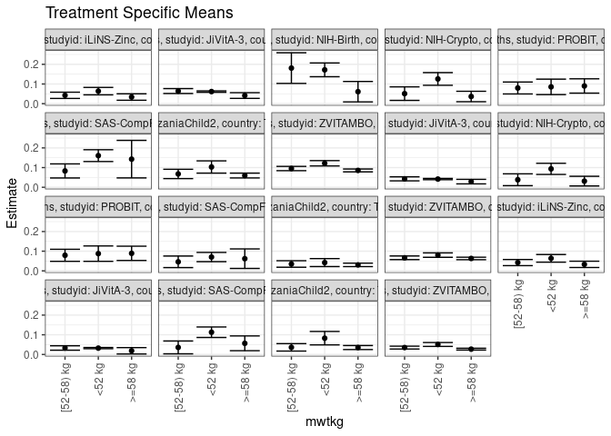

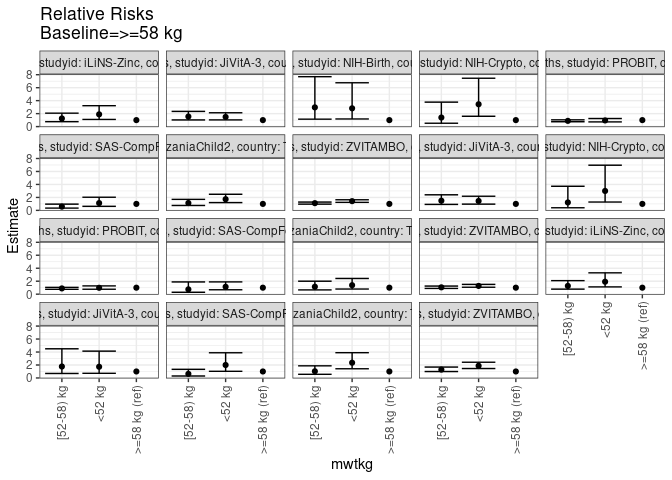

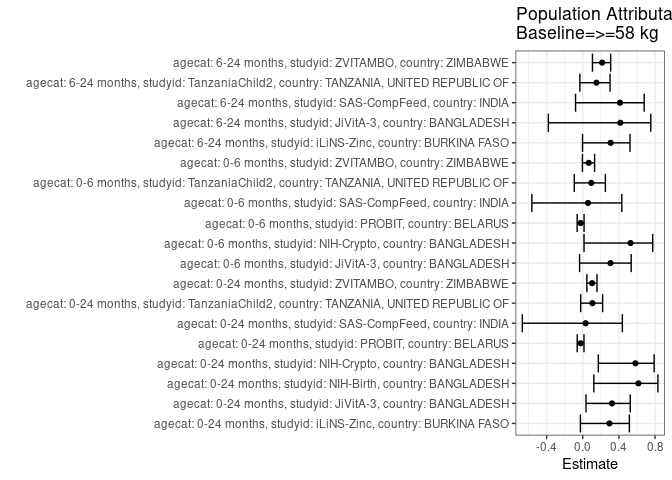

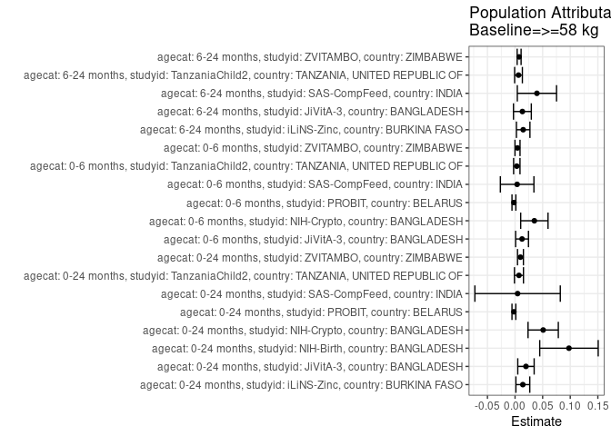

## Results Table

### Parameter: TSM

| agecat | studyid | country | intervention_level | baseline_level | estimate | ci_lower | ci_upper |
| --- | --- | --- | --- | --- | --- | --- | --- |
| 0-24 months | iLiNS-Zinc | BURKINA FASO | >=58 kg | NA | 0.0337524 | 0.0173676 | 0.0501371 |
| 0-24 months | iLiNS-Zinc | BURKINA FASO | <52 kg | NA | 0.0637543 | 0.0449326 | 0.0825760 |
| 0-24 months | iLiNS-Zinc | BURKINA FASO | [52-58) kg | NA | 0.0423896 | 0.0265751 | 0.0582041 |
| 0-24 months | JiVitA-3 | BANGLADESH | >=58 kg | NA | 0.0413381 | 0.0267984 | 0.0558777 |
| 0-24 months | JiVitA-3 | BANGLADESH | <52 kg | NA | 0.0614279 | 0.0577043 | 0.0651514 |
| 0-24 months | JiVitA-3 | BANGLADESH | [52-58) kg | NA | 0.0641619 | 0.0516952 | 0.0766287 |
| 0-24 months | NIH-Birth | BANGLADESH | >=58 kg | NA | 0.0609756 | 0.0091427 | 0.1128086 |
| 0-24 months | NIH-Birth | BANGLADESH | <52 kg | NA | 0.1718750 | 0.1369118 | 0.2068382 |
| 0-24 months | NIH-Birth | BANGLADESH | [52-58) kg | NA | 0.1808511 | 0.1029803 | 0.2587218 |
| 0-24 months | NIH-Crypto | BANGLADESH | >=58 kg | NA | 0.0364583 | 0.0099295 | 0.0629872 |
| 0-24 months | NIH-Crypto | BANGLADESH | <52 kg | NA | 0.1256158 | 0.0933571 | 0.1578744 |
| 0-24 months | NIH-Crypto | BANGLADESH | [52-58) kg | NA | 0.0509554 | 0.0165343 | 0.0853765 |
| 0-24 months | PROBIT | BELARUS | >=58 kg | NA | 0.0898741 | 0.0535375 | 0.1262107 |
| 0-24 months | PROBIT | BELARUS | <52 kg | NA | 0.0853839 | 0.0461501 | 0.1246176 |
| 0-24 months | PROBIT | BELARUS | [52-58) kg | NA | 0.0796192 | 0.0492902 | 0.1099482 |
| 0-24 months | SAS-CompFeed | INDIA | >=58 kg | NA | 0.1429174 | 0.0475331 | 0.2383016 |
| 0-24 months | SAS-CompFeed | INDIA | <52 kg | NA | 0.1608284 | 0.1307957 | 0.1908611 |
| 0-24 months | SAS-CompFeed | INDIA | [52-58) kg | NA | 0.0830284 | 0.0472111 | 0.1188457 |
| 0-24 months | TanzaniaChild2 | TANZANIA, UNITED REPUBLIC OF | >=58 kg | NA | 0.0596577 | 0.0474964 | 0.0718191 |
| 0-24 months | TanzaniaChild2 | TANZANIA, UNITED REPUBLIC OF | <52 kg | NA | 0.1029847 | 0.0718832 | 0.1340861 |
| 0-24 months | TanzaniaChild2 | TANZANIA, UNITED REPUBLIC OF | [52-58) kg | NA | 0.0677212 | 0.0440391 | 0.0914033 |
| 0-24 months | ZVITAMBO | ZIMBABWE | >=58 kg | NA | 0.0855584 | 0.0783052 | 0.0928115 |
| 0-24 months | ZVITAMBO | ZIMBABWE | <52 kg | NA | 0.1217809 | 0.1082680 | 0.1352938 |
| 0-24 months | ZVITAMBO | ZIMBABWE | [52-58) kg | NA | 0.0952557 | 0.0843164 | 0.1061950 |
| 0-6 months | JiVitA-3 | BANGLADESH | >=58 kg | NA | 0.0287190 | 0.0172118 | 0.0402263 |
| 0-6 months | JiVitA-3 | BANGLADESH | <52 kg | NA | 0.0416963 | 0.0385220 | 0.0448705 |
| 0-6 months | JiVitA-3 | BANGLADESH | [52-58) kg | NA | 0.0427846 | 0.0325234 | 0.0530458 |
| 0-6 months | NIH-Crypto | BANGLADESH | >=58 kg | NA | 0.0312500 | 0.0066227 | 0.0558773 |
| 0-6 months | NIH-Crypto | BANGLADESH | <52 kg | NA | 0.0935961 | 0.0652454 | 0.1219467 |
| 0-6 months | NIH-Crypto | BANGLADESH | [52-58) kg | NA | 0.0382166 | 0.0082076 | 0.0682255 |
| 0-6 months | PROBIT | BELARUS | >=58 kg | NA | 0.0891046 | 0.0527813 | 0.1254278 |
| 0-6 months | PROBIT | BELARUS | <52 kg | NA | 0.0876435 | 0.0485971 | 0.1266900 |
| 0-6 months | PROBIT | BELARUS | [52-58) kg | NA | 0.0791386 | 0.0485135 | 0.1097638 |
| 0-6 months | SAS-CompFeed | INDIA | >=58 kg | NA | 0.0619469 | 0.0123761 | 0.1115177 |
| 0-6 months | SAS-CompFeed | INDIA | <52 kg | NA | 0.0702371 | 0.0468032 | 0.0936709 |
| 0-6 months | SAS-CompFeed | INDIA | [52-58) kg | NA | 0.0460251 | 0.0166561 | 0.0753941 |
| 0-6 months | TanzaniaChild2 | TANZANIA, UNITED REPUBLIC OF | >=58 kg | NA | 0.0304266 | 0.0216475 | 0.0392057 |
| 0-6 months | TanzaniaChild2 | TANZANIA, UNITED REPUBLIC OF | <52 kg | NA | 0.0420894 | 0.0219161 | 0.0622628 |
| 0-6 months | TanzaniaChild2 | TANZANIA, UNITED REPUBLIC OF | [52-58) kg | NA | 0.0349926 | 0.0184674 | 0.0515179 |
| 0-6 months | ZVITAMBO | ZIMBABWE | >=58 kg | NA | 0.0631135 | 0.0568067 | 0.0694204 |
| 0-6 months | ZVITAMBO | ZIMBABWE | <52 kg | NA | 0.0801802 | 0.0689711 | 0.0913893 |
| 0-6 months | ZVITAMBO | ZIMBABWE | [52-58) kg | NA | 0.0664754 | 0.0572313 | 0.0757195 |
| 6-24 months | iLiNS-Zinc | BURKINA FASO | >=58 kg | NA | 0.0331257 | 0.0171604 | 0.0490909 |
| 6-24 months | iLiNS-Zinc | BURKINA FASO | <52 kg | NA | 0.0636421 | 0.0441963 | 0.0830878 |
| 6-24 months | iLiNS-Zinc | BURKINA FASO | [52-58) kg | NA | 0.0421960 | 0.0265685 | 0.0578235 |
| 6-24 months | JiVitA-3 | BANGLADESH | >=58 kg | NA | 0.0186916 | 0.0025656 | 0.0348176 |
| 6-24 months | JiVitA-3 | BANGLADESH | <52 kg | NA | 0.0322766 | 0.0292544 | 0.0352988 |
| 6-24 months | JiVitA-3 | BANGLADESH | [52-58) kg | NA | 0.0329670 | 0.0217078 | 0.0442263 |
| 6-24 months | SAS-CompFeed | INDIA | >=58 kg | NA | 0.0566038 | 0.0190352 | 0.0941723 |
| 6-24 months | SAS-CompFeed | INDIA | <52 kg | NA | 0.1130104 | 0.0863447 | 0.1396762 |
| 6-24 months | SAS-CompFeed | INDIA | [52-58) kg | NA | 0.0358744 | 0.0032414 | 0.0685075 |
| 6-24 months | TanzaniaChild2 | TANZANIA, UNITED REPUBLIC OF | >=58 kg | NA | 0.0351946 | 0.0249921 | 0.0453971 |
| 6-24 months | TanzaniaChild2 | TANZANIA, UNITED REPUBLIC OF | <52 kg | NA | 0.0827686 | 0.0486390 | 0.1168982 |
| 6-24 months | TanzaniaChild2 | TANZANIA, UNITED REPUBLIC OF | [52-58) kg | NA | 0.0362491 | 0.0173333 | 0.0551650 |
| 6-24 months | ZVITAMBO | ZIMBABWE | >=58 kg | NA | 0.0270962 | 0.0225953 | 0.0315970 |
| 6-24 months | ZVITAMBO | ZIMBABWE | <52 kg | NA | 0.0508829 | 0.0410019 | 0.0607638 |
| 6-24 months | ZVITAMBO | ZIMBABWE | [52-58) kg | NA | 0.0350056 | 0.0278678 | 0.0421435 |

### Parameter: E(Y)

| agecat | studyid | country | intervention_level | baseline_level | estimate | ci_lower | ci_upper |
| --- | --- | --- | --- | --- | --- | --- | --- |
| 0-24 months | iLiNS-Zinc | BURKINA FASO | NA | NA | 0.0478707 | 0.0359037 | 0.0598376 |
| 0-24 months | JiVitA-3 | BANGLADESH | NA | NA | 0.0610956 | 0.0576148 | 0.0645765 |
| 0-24 months | NIH-Birth | BANGLADESH | NA | NA | 0.1586538 | 0.1299648 | 0.1873429 |
| 0-24 months | NIH-Crypto | BANGLADESH | NA | NA | 0.0874172 | 0.0672569 | 0.1075775 |
| 0-24 months | PROBIT | BELARUS | NA | NA | 0.0877868 | 0.0528398 | 0.1227338 |
| 0-24 months | SAS-CompFeed | INDIA | NA | NA | 0.1475300 | 0.1183178 | 0.1767423 |
| 0-24 months | TanzaniaChild2 | TANZANIA, UNITED REPUBLIC OF | NA | NA | 0.0667517 | 0.0566626 | 0.0768408 |
| 0-24 months | ZVITAMBO | ZIMBABWE | NA | NA | 0.0953617 | 0.0899142 | 0.1008093 |
| 0-6 months | JiVitA-3 | BANGLADESH | NA | NA | 0.0414120 | 0.0384288 | 0.0443951 |
| 0-6 months | NIH-Crypto | BANGLADESH | NA | NA | 0.0662252 | 0.0484753 | 0.0839750 |
| 0-6 months | PROBIT | BELARUS | NA | NA | 0.0870607 | 0.0521007 | 0.1220207 |
| 0-6 months | SAS-CompFeed | INDIA | NA | NA | 0.0657277 | 0.0426068 | 0.0888486 |
| 0-6 months | TanzaniaChild2 | TANZANIA, UNITED REPUBLIC OF | NA | NA | 0.0335884 | 0.0263056 | 0.0408712 |
| 0-6 months | ZVITAMBO | ZIMBABWE | NA | NA | 0.0675481 | 0.0628829 | 0.0722134 |
| 6-24 months | iLiNS-Zinc | BURKINA FASO | NA | NA | 0.0478707 | 0.0359037 | 0.0598376 |
| 6-24 months | JiVitA-3 | BANGLADESH | NA | NA | 0.0319875 | 0.0290997 | 0.0348754 |
| 6-24 months | SAS-CompFeed | INDIA | NA | NA | 0.0962373 | 0.0722060 | 0.1202687 |
| 6-24 months | TanzaniaChild2 | TANZANIA, UNITED REPUBLIC OF | NA | NA | 0.0414560 | 0.0326689 | 0.0502431 |
| 6-24 months | ZVITAMBO | ZIMBABWE | NA | NA | 0.0344828 | 0.0308596 | 0.0381059 |

### Parameter: RR

| agecat | studyid | country | intervention_level | baseline_level | estimate | ci_lower | ci_upper |
| --- | --- | --- | --- | --- | --- | --- | --- |
| 0-24 months | iLiNS-Zinc | BURKINA FASO | >=58 kg | >=58 kg | 1.0000000 | 1.0000000 | 1.0000000 |
| 0-24 months | iLiNS-Zinc | BURKINA FASO | <52 kg | >=58 kg | 1.8888843 | 1.1078637 | 3.2205083 |
| 0-24 months | iLiNS-Zinc | BURKINA FASO | [52-58) kg | >=58 kg | 1.2559003 | 0.7612674 | 2.0719204 |
| 0-24 months | JiVitA-3 | BANGLADESH | >=58 kg | >=58 kg | 1.0000000 | 1.0000000 | 1.0000000 |
| 0-24 months | JiVitA-3 | BANGLADESH | <52 kg | >=58 kg | 1.4859874 | 1.0358710 | 2.1316927 |
| 0-24 months | JiVitA-3 | BANGLADESH | [52-58) kg | >=58 kg | 1.5521260 | 1.0276593 | 2.3442548 |
| 0-24 months | NIH-Birth | BANGLADESH | >=58 kg | >=58 kg | 1.0000000 | 1.0000000 | 1.0000000 |
| 0-24 months | NIH-Birth | BANGLADESH | <52 kg | >=58 kg | 2.8187500 | 1.1761332 | 6.7554864 |
| 0-24 months | NIH-Birth | BANGLADESH | [52-58) kg | >=58 kg | 2.9659574 | 1.1437460 | 7.6913089 |
| 0-24 months | NIH-Crypto | BANGLADESH | >=58 kg | >=58 kg | 1.0000000 | 1.0000000 | 1.0000000 |
| 0-24 months | NIH-Crypto | BANGLADESH | <52 kg | >=58 kg | 3.4454609 | 1.5926859 | 7.4535732 |
| 0-24 months | NIH-Crypto | BANGLADESH | [52-58) kg | >=58 kg | 1.3976342 | 0.5178396 | 3.7721749 |
| 0-24 months | PROBIT | BELARUS | >=58 kg | >=58 kg | 1.0000000 | 1.0000000 | 1.0000000 |
| 0-24 months | PROBIT | BELARUS | <52 kg | >=58 kg | 0.9500388 | 0.7261923 | 1.2428853 |
| 0-24 months | PROBIT | BELARUS | [52-58) kg | >=58 kg | 0.8858971 | 0.7510353 | 1.0449757 |
| 0-24 months | SAS-CompFeed | INDIA | >=58 kg | >=58 kg | 1.0000000 | 1.0000000 | 1.0000000 |
| 0-24 months | SAS-CompFeed | INDIA | <52 kg | >=58 kg | 1.1253245 | 0.6248814 | 2.0265530 |
| 0-24 months | SAS-CompFeed | INDIA | [52-58) kg | >=58 kg | 0.5809539 | 0.3504499 | 0.9630689 |
| 0-24 months | TanzaniaChild2 | TANZANIA, UNITED REPUBLIC OF | >=58 kg | >=58 kg | 1.0000000 | 1.0000000 | 1.0000000 |
| 0-24 months | TanzaniaChild2 | TANZANIA, UNITED REPUBLIC OF | <52 kg | >=58 kg | 1.7262585 | 1.1988724 | 2.4856428 |
| 0-24 months | TanzaniaChild2 | TANZANIA, UNITED REPUBLIC OF | [52-58) kg | >=58 kg | 1.1351617 | 0.7572054 | 1.7017736 |
| 0-24 months | ZVITAMBO | ZIMBABWE | >=58 kg | >=58 kg | 1.0000000 | 1.0000000 | 1.0000000 |
| 0-24 months | ZVITAMBO | ZIMBABWE | <52 kg | >=58 kg | 1.4233660 | 1.2377769 | 1.6367818 |
| 0-24 months | ZVITAMBO | ZIMBABWE | [52-58) kg | >=58 kg | 1.1133418 | 0.9651827 | 1.2842438 |
| 0-6 months | JiVitA-3 | BANGLADESH | >=58 kg | >=58 kg | 1.0000000 | 1.0000000 | 1.0000000 |
| 0-6 months | JiVitA-3 | BANGLADESH | <52 kg | >=58 kg | 1.4518699 | 0.9651048 | 2.1841424 |
| 0-6 months | JiVitA-3 | BANGLADESH | [52-58) kg | >=58 kg | 1.4897669 | 0.9231997 | 2.4040360 |
| 0-6 months | NIH-Crypto | BANGLADESH | >=58 kg | >=58 kg | 1.0000000 | 1.0000000 | 1.0000000 |
| 0-6 months | NIH-Crypto | BANGLADESH | <52 kg | >=58 kg | 2.9950739 | 1.2874825 | 6.9674482 |
| 0-6 months | NIH-Crypto | BANGLADESH | [52-58) kg | >=58 kg | 1.2229299 | 0.4020223 | 3.7200860 |
| 0-6 months | PROBIT | BELARUS | >=58 kg | >=58 kg | 1.0000000 | 1.0000000 | 1.0000000 |
| 0-6 months | PROBIT | BELARUS | <52 kg | >=58 kg | 0.9836029 | 0.7599528 | 1.2730721 |
| 0-6 months | PROBIT | BELARUS | [52-58) kg | >=58 kg | 0.8881546 | 0.7500700 | 1.0516599 |
| 0-6 months | SAS-CompFeed | INDIA | >=58 kg | >=58 kg | 1.0000000 | 1.0000000 | 1.0000000 |
| 0-6 months | SAS-CompFeed | INDIA | <52 kg | >=58 kg | 1.1338267 | 0.6789947 | 1.8933327 |
| 0-6 months | SAS-CompFeed | INDIA | [52-58) kg | >=58 kg | 0.7429767 | 0.2925146 | 1.8871342 |
| 0-6 months | TanzaniaChild2 | TANZANIA, UNITED REPUBLIC OF | >=58 kg | >=58 kg | 1.0000000 | 1.0000000 | 1.0000000 |
| 0-6 months | TanzaniaChild2 | TANZANIA, UNITED REPUBLIC OF | <52 kg | >=58 kg | 1.3833127 | 0.7905615 | 2.4205000 |
| 0-6 months | TanzaniaChild2 | TANZANIA, UNITED REPUBLIC OF | [52-58) kg | >=58 kg | 1.1500687 | 0.6612427 | 2.0002611 |
| 0-6 months | ZVITAMBO | ZIMBABWE | >=58 kg | >=58 kg | 1.0000000 | 1.0000000 | 1.0000000 |
| 0-6 months | ZVITAMBO | ZIMBABWE | <52 kg | >=58 kg | 1.2704121 | 1.0698017 | 1.5086413 |
| 0-6 months | ZVITAMBO | ZIMBABWE | [52-58) kg | >=58 kg | 1.0532679 | 0.8874848 | 1.2500194 |
| 6-24 months | iLiNS-Zinc | BURKINA FASO | >=58 kg | >=58 kg | 1.0000000 | 1.0000000 | 1.0000000 |
| 6-24 months | iLiNS-Zinc | BURKINA FASO | <52 kg | >=58 kg | 1.9212326 | 1.1209578 | 3.2928399 |
| 6-24 months | iLiNS-Zinc | BURKINA FASO | [52-58) kg | >=58 kg | 1.2738160 | 0.7777665 | 2.0862395 |
| 6-24 months | JiVitA-3 | BANGLADESH | >=58 kg | >=58 kg | 1.0000000 | 1.0000000 | 1.0000000 |
| 6-24 months | JiVitA-3 | BANGLADESH | <52 kg | >=58 kg | 1.7267972 | 0.7211387 | 4.1348890 |
| 6-24 months | JiVitA-3 | BANGLADESH | [52-58) kg | >=58 kg | 1.7637363 | 0.6919969 | 4.4953461 |
| 6-24 months | SAS-CompFeed | INDIA | >=58 kg | >=58 kg | 1.0000000 | 1.0000000 | 1.0000000 |
| 6-24 months | SAS-CompFeed | INDIA | <52 kg | >=58 kg | 1.9965179 | 1.0255200 | 3.8868901 |
| 6-24 months | SAS-CompFeed | INDIA | [52-58) kg | >=58 kg | 0.6337818 | 0.3023311 | 1.3286072 |
| 6-24 months | TanzaniaChild2 | TANZANIA, UNITED REPUBLIC OF | >=58 kg | >=58 kg | 1.0000000 | 1.0000000 | 1.0000000 |
| 6-24 months | TanzaniaChild2 | TANZANIA, UNITED REPUBLIC OF | <52 kg | >=58 kg | 2.3517380 | 1.4207462 | 3.8927935 |
| 6-24 months | TanzaniaChild2 | TANZANIA, UNITED REPUBLIC OF | [52-58) kg | >=58 kg | 1.0299612 | 0.5670100 | 1.8709020 |
| 6-24 months | ZVITAMBO | ZIMBABWE | >=58 kg | >=58 kg | 1.0000000 | 1.0000000 | 1.0000000 |
| 6-24 months | ZVITAMBO | ZIMBABWE | <52 kg | >=58 kg | 1.8778619 | 1.4544637 | 2.4245125 |
| 6-24 months | ZVITAMBO | ZIMBABWE | [52-58) kg | >=58 kg | 1.2919036 | 0.9931102 | 1.6805937 |

### Parameter: PAR

| agecat | studyid | country | intervention_level | baseline_level | estimate | ci_lower | ci_upper |
| --- | --- | --- | --- | --- | --- | --- | --- |
| 0-24 months | iLiNS-Zinc | BURKINA FASO | >=58 kg | NA | 0.0141183 | 0.0015514 | 0.0266852 |
| 0-24 months | JiVitA-3 | BANGLADESH | >=58 kg | NA | 0.0197576 | 0.0049197 | 0.0345954 |
| 0-24 months | NIH-Birth | BANGLADESH | >=58 kg | NA | 0.0976782 | 0.0447291 | 0.1506274 |
| 0-24 months | NIH-Crypto | BANGLADESH | >=58 kg | NA | 0.0509589 | 0.0235314 | 0.0783864 |
| 0-24 months | PROBIT | BELARUS | >=58 kg | NA | -0.0020873 | -0.0055767 | 0.0014022 |
| 0-24 months | SAS-CompFeed | INDIA | >=58 kg | NA | 0.0046127 | -0.0727406 | 0.0819660 |
| 0-24 months | TanzaniaChild2 | TANZANIA, UNITED REPUBLIC OF | >=58 kg | NA | 0.0070940 | -0.0010563 | 0.0152443 |
| 0-24 months | ZVITAMBO | ZIMBABWE | >=58 kg | NA | 0.0098034 | 0.0044512 | 0.0151555 |
| 0-6 months | JiVitA-3 | BANGLADESH | >=58 kg | NA | 0.0126929 | 0.0010543 | 0.0243316 |
| 0-6 months | NIH-Crypto | BANGLADESH | >=58 kg | NA | 0.0349752 | 0.0102146 | 0.0597358 |
| 0-6 months | PROBIT | BELARUS | >=58 kg | NA | -0.0020439 | -0.0055666 | 0.0014789 |
| 0-6 months | SAS-CompFeed | INDIA | >=58 kg | NA | 0.0037808 | -0.0266346 | 0.0341961 |
| 0-6 months | TanzaniaChild2 | TANZANIA, UNITED REPUBLIC OF | >=58 kg | NA | 0.0031619 | -0.0026223 | 0.0089461 |
| 0-6 months | ZVITAMBO | ZIMBABWE | >=58 kg | NA | 0.0044346 | -0.0001308 | 0.0090000 |
| 6-24 months | iLiNS-Zinc | BURKINA FASO | >=58 kg | NA | 0.0147450 | 0.0025323 | 0.0269578 |
| 6-24 months | JiVitA-3 | BANGLADESH | >=58 kg | NA | 0.0132959 | -0.0028644 | 0.0294562 |
| 6-24 months | SAS-CompFeed | INDIA | >=58 kg | NA | 0.0396336 | 0.0041026 | 0.0751645 |
| 6-24 months | TanzaniaChild2 | TANZANIA, UNITED REPUBLIC OF | >=58 kg | NA | 0.0062614 | -0.0007376 | 0.0132604 |
| 6-24 months | ZVITAMBO | ZIMBABWE | >=58 kg | NA | 0.0073866 | 0.0038369 | 0.0109363 |

### Parameter: PAF

| agecat | studyid | country | intervention_level | baseline_level | estimate | ci_lower | ci_upper |
| --- | --- | --- | --- | --- | --- | --- | --- |
| 0-24 months | iLiNS-Zinc | BURKINA FASO | >=58 kg | NA | 0.2949264 | -0.0265285 | 0.5157185 |
| 0-24 months | JiVitA-3 | BANGLADESH | >=58 kg | NA | 0.3233874 | 0.0355687 | 0.5253113 |
| 0-24 months | NIH-Birth | BANGLADESH | >=58 kg | NA | 0.6156689 | 0.1221060 | 0.8317446 |
| 0-24 months | NIH-Crypto | BANGLADESH | >=58 kg | NA | 0.5829388 | 0.1719680 | 0.7899356 |
| 0-24 months | PROBIT | BELARUS | >=58 kg | NA | -0.0237768 | -0.0619067 | 0.0129840 |
| 0-24 months | SAS-CompFeed | INDIA | >=58 kg | NA | 0.0312660 | -0.6698026 | 0.4379902 |
| 0-24 months | TanzaniaChild2 | TANZANIA, UNITED REPUBLIC OF | >=58 kg | NA | 0.1062740 | -0.0234907 | 0.2195863 |
| 0-24 months | ZVITAMBO | ZIMBABWE | >=58 kg | NA | 0.1028020 | 0.0451708 | 0.1569547 |
| 0-6 months | JiVitA-3 | BANGLADESH | >=58 kg | NA | 0.3065044 | -0.0356221 | 0.5356065 |
| 0-6 months | NIH-Crypto | BANGLADESH | >=58 kg | NA | 0.5281250 | 0.0134939 | 0.7742883 |
| 0-6 months | PROBIT | BELARUS | >=58 kg | NA | -0.0234764 | -0.0624574 | 0.0140744 |
| 0-6 months | SAS-CompFeed | INDIA | >=58 kg | NA | 0.0575221 | -0.5639304 | 0.4320306 |
| 0-6 months | TanzaniaChild2 | TANZANIA, UNITED REPUBLIC OF | >=58 kg | NA | 0.0941358 | -0.0942285 | 0.2500744 |
| 0-6 months | ZVITAMBO | ZIMBABWE | >=58 kg | NA | 0.0656510 | -0.0042800 | 0.1307125 |
| 6-24 months | iLiNS-Zinc | BURKINA FASO | >=58 kg | NA | 0.3080180 | -0.0030087 | 0.5225973 |
| 6-24 months | JiVitA-3 | BANGLADESH | >=58 kg | NA | 0.4156597 | -0.3815110 | 0.7528405 |
| 6-24 months | SAS-CompFeed | INDIA | >=58 kg | NA | 0.4118315 | -0.0801834 | 0.6797375 |
| 6-24 months | TanzaniaChild2 | TANZANIA, UNITED REPUBLIC OF | >=58 kg | NA | 0.1510368 | -0.0324119 | 0.3018885 |
| 6-24 months | ZVITAMBO | ZIMBABWE | >=58 kg | NA | 0.2142110 | 0.1069012 | 0.3086270 |